# Visualizing High-Dimensional Data & Advanced Visualizations

Fundamentals of Data Science

MTH-391A | Spring 2025 | University of Portland

March 10, 2025

# Objectives

- **Understand challenges in visualizing high-dimensional data**
- **Introduce the method of Principal Component Analysis**
- **Learn how PCA reduces dimensionality while preserving variance**
- **Activity: Implement PCA Visualizations**

# What is High-Dimensional Data?

**High-dimensional data** refers to datasets with a large number of variables (features/dimensions) relative to the number of observations.

**Challenges:**

- *Curse of Dimensionality:* As dimensions increase, data becomes sparse, making patterns harder to detect.
- *Difficult to Visualize:* We can easily plot 2D or 3D data, but what about 100+ dimensions?
- *Computational Complexity:* More features mean increased storage, processing, and algorithmic complexity.

**Methods:**

- *Dimensionality Reduction:* Reducing dimensions help to simplify high-dimensional datasets, making patterns more interpretable while improving efficiency (e.g. Principal Component Analysis).

# Why Dimensionality Reduction?

**Identify Patterns & Relationships**

- Helps uncover hidden structures in complex datasets.
- Useful for data compression, visualization, and feature selection.

**Reduce Noise & Redundancy**

- Eliminates irrelevant or highly correlated features.
- Makes data easier to interpret and less computationally expensive.

# Case Study I

**United States Data Sets**

- The `usdata` package: Data on the States and Counties of the United States
- The `usa` package: Updated US facts

**Load Packages**

```r
library(usdata)
library(usa)
```

# Simple Example: The `facts` and `state_stats` Data Set (1/2)

```r
facts_sub <- facts %>%
  select(name,life_exp,college) %>%
  mutate(region=state.region)
state_stats_sub <- state_stats %>%
  select(abbr,state,income,med_income,poverty,unempl,land_area,pop2010)

df <- facts_sub %>%
  left_join(state_stats_sub,by=c("name" = "state")) %>%
  filter(!name %in% c("District of Columbia", "Puerto Rico")) %>%
  select(-name) %>%
  mutate(pop_density = pop2010/land_area) %>%
  select(-land_area,-pop2010)
glimpse(df)
```

```
## Rows: 50
## Columns: 9
## $ life_exp    <dbl> 75.3, 78.3, 79.7, 75.9, 81.5, 80.3, 81.0, 78.6, 80.0, 77.7…
## $ college     <dbl> 0.2339, 0.2713, 0.2708, 0.2137, 0.3141, 0.3841, 0.3676, 0.…
## $ region      <fct> South, West, West, South, West, West, Northeast, South, So…
## $ abbr        <fct> AL, AK, AZ, AR, CA, CO, CT, DE, FL, GA, HI, ID, IL, IN, IA…
## $ income      <dbl> 22984, 30726, 25680, 21274, 29188, 30151, 36775, 29007, 26…
## $ med_income  <dbl> 42081, 66521, 50448, 39267, 60883, 56456, 67740, 57599, 47…
## $ poverty     <dbl> 17.1, 9.5, 15.3, 18.0, 13.7, 12.2, 9.2, 11.0, 13.8, 15.7, …
## $ unempl      <dbl> 7.6, 7.1, 8.7, 7.6, 10.9, 7.8, 7.8, 7.0, 9.4, 9.1, 6.4, 8.…
## $ pop_density <dbl> 94.376638, 1.244620, 56.270688, 56.037112, 239.145863, 48.…
```

- Each row is a state (or an observation), excluding DC.
- Seven numerical
  - `life_exp` | Life expectancy in years
  - `college` | Percent adult population with at least a bachelor’s degree or greater
  - `income` | Average income per capita
  - `med_income` | Median household income
  - `poverty` | Poverty rate
  - `unempl` | Unemployment rate
  - `pop_density` | Population density, which is `pop2010` / `land_area`
- Two categorical variable.
  - `abbr` | State abbreviation
  - `region` | Census region to which each state belongs

# Simple Example: The `facts` and `state_stats` Data Set (2/2)

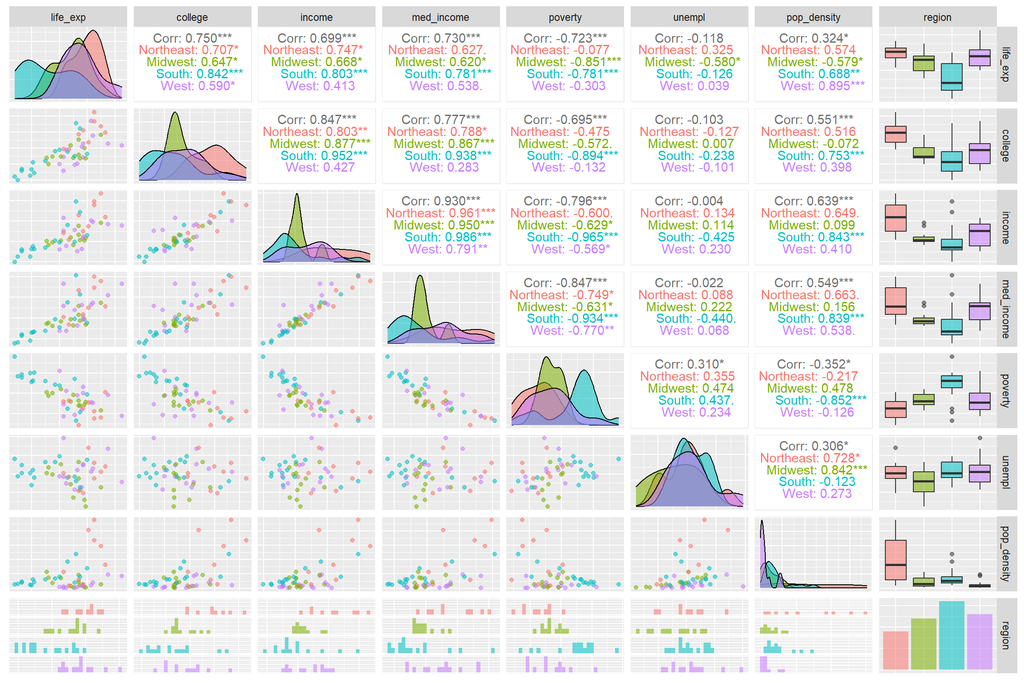

- We can only visualize one to two variables at a time
- Categorical variables can be added through colors or shapes

$\dagger$ Can we visualize or represent all features in a two-dimensional space?

# Principal Component Analysis: R Example (1/3)

**Computing the Principal Components**

```r
# select the numerical variables
sub_num <- df %>%
  select(-abbr,-region)

# apply principal component analysis
pca_res <- prcomp(sub_num, center = TRUE, scale = TRUE)

# convert principal component into a data frame and merge the categorical variables
pc <- tibble(data.frame(pca_res$x,
                        abbr=df$abbr,
                        region=df$region))

# view principal components
glimpse(pc)
```

```
## Rows: 50
## Columns: 9
## $ PC1    <dbl> -2.81823565, 1.34671603, -0.59066599, -3.38204922, 1.52869410, …
## $ PC2    <dbl> -0.3753737, 0.7158912, -0.3396640, -0.2871326, -1.4757631, 0.29…
## $ PC3    <dbl> 0.762569633, -0.330127302, -1.013110178, 0.465246298, -1.763041…
## $ PC4    <dbl> -0.295124993, -1.985938857, 0.251181457, -0.016770158, 0.156299…
## $ PC5    <dbl> 0.36861978, 0.40949364, -0.15767992, -0.07776277, -0.08938850, …
## $ PC6    <dbl> -0.039950619, -0.447131525, -0.397856523, -0.157909221, -0.4952…
## $ PC7    <dbl> -0.0194314032, 0.1464910527, -0.0290094878, -0.0090896835, 0.16…
## $ abbr   <fct> AL, AK, AZ, AR, CA, CO, CT, DE, FL, GA, HI, ID, IL, IN, IA, KS,…
## $ region <fct> South, West, West, South, West, West, Northeast, South, South, …
```

$\star$ **Key Idea:** The results of the PCA are called principal components or new variables. a linear combination of the original variables.

# Principal Component Analysis: R Example (2/3)

**Variance Explained**

```r
# get standard deviations
sd <- pca_res$sdev

# create tibble of percent variances
ve <- tibble(pc = seq(1,length(sd)),
             ve = sd/sum(sd),
             cumve = cumsum(ve))
```

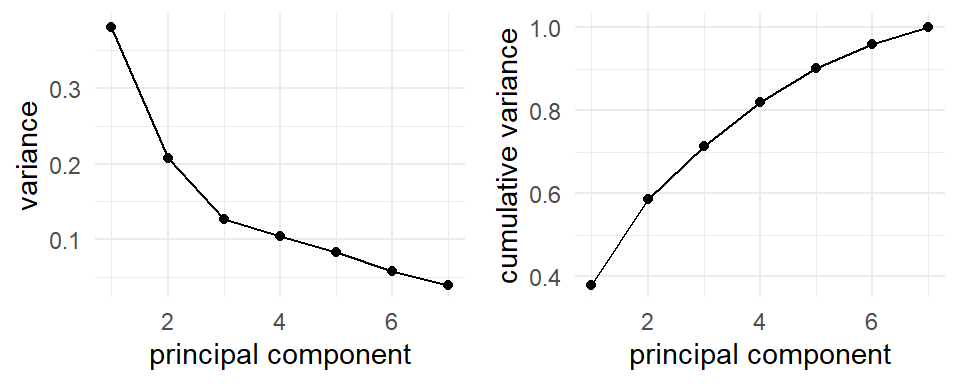

$\star$ **Key Idea:** Percent variance explained shows how much variability each principal component captures, while cumulative variance shows the total variability retained across components.

# Principal Component Analysis: R Example (3/3)

**Visualize the Dominant Principal Components**

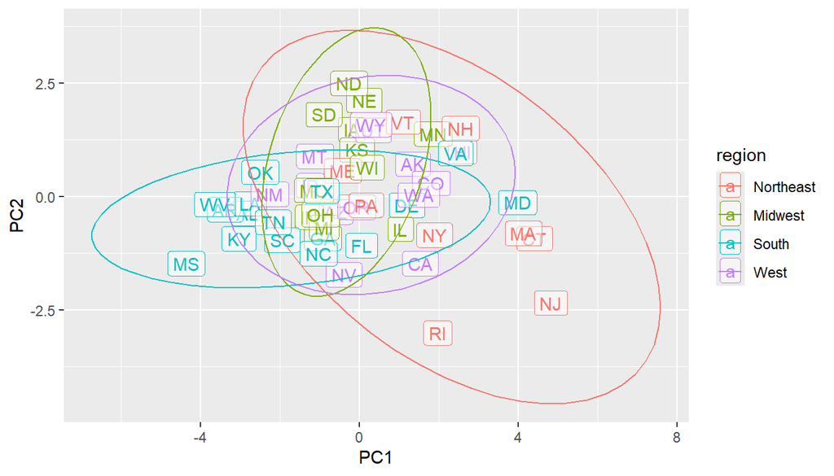

- Points that are far apart indicate greater differences, while clusters suggest similarities within states
- Clustering of points may reveal inherent state similarities
- If clusters intersect, then it means these groups of states are similar

$\star$ **Key Idea:** PCA plot is to visualize high-dimensional data by projecting it onto principal components that capture the most variance, revealing patterns, groupings, and relationships among data points.

# Principal Component Analysis (1/2)

**Principal Component Analysis (PCA)** is a technique used to reduce the number of variables in a dataset while preserving as much important information as possible.

- Why use PCA?
  - Simplifies complex data
  - Helps visualize high-dimensional data
  - Removes redundant information
- How does it work?
  - Finds new axes (principal components) that best capture variation in data
  - First principal component captures the most variance
  - Each following component captures the next most variance, and so on

# Principal Component Analysis (2/2)

- When to use PCA?
  - Relationships between variables are mostly linear
  - When you have too many features (variables) and want to simplify the dataset
  - Useful when working with datasets that have many correlated variables
  - Helps in cases where data has a lot of noise
  - Useful for pre-processing data sets for advanced models
- When not to use PCA?
  - When interpretability is important—PCA transforms features into combinations, making them hard to interpret.
  - When original features are already independent—PCA won’t provide much benefit.
  - When data is not linear—PCA captures linear relationships, so nonlinear structures may require other techniques

# Advanced Example: The `digits` data set (1/4)

**Loading the `digits` data set** (using Python)

```python
# load packages
from sklearn import datasets
import pandas as pd

# load the `digits` data set
digits = datasets.load_digits()
df_digits = pd.DataFrame(digits.data,
                         columns=digits.feature_names)
```

- The `digits` data set loaded from the`datasets` package in Python
- The `digits` data set consists of 1,797 grayscale images of handwritten digits.
- Each image is 8-by-8 pixels and has an associated label denoting which digit the image represents (0-9).
- The `digits.data` contains the pixels information as variables
- The `digits.feature_names` contains the names of the variables
- The `digits.target` contains the digit labels

# Advanced Example: The `digits` data set (2/4)

**Example digits in the `digits` data set**

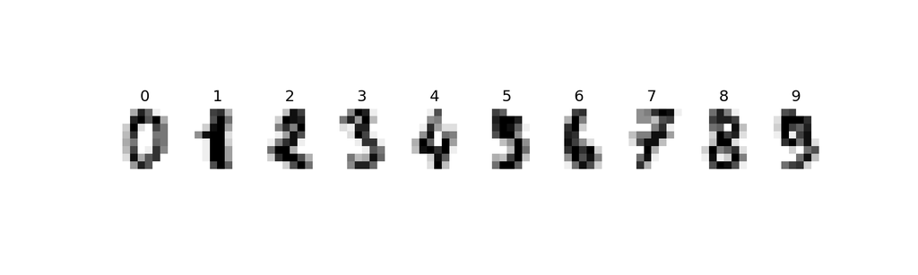

$\star$ **Key Idea:** The images are 8-by-8 pixels in grayscale, which means there are 64 variables that represents an image containing handwritten digits.

# Advanced Example: The `digits` data set (3/4)

**Principal Component Analysis** (using Python)

```python
# load packages
from sklearn.decomposition import PCA

# apply PCA with defined number of components
pca = PCA(n_components=2)

# extract principal components
pca_result = pca.fit_transform(df_digits)

# convert results into a dataframe and merge the digit labels
digits_pca = pd.DataFrame(pca_result)
digits_pca = digits_pca.rename(columns={0: "PC1", 1: "PC2"})
digits_pca['digit'] = (digits.target)

# save results
digits_pca.to_csv("digits_pca.csv",header=True,index=False)
```

- The function `PCA` form the `sklearn.decomposition` package establishes the method
- The function `fit_transform` computes the principal components and then applies the transformation to project the data onto the new principal components

$\star$ **Key Idea:** Use Python for data sub-setting and complex computations (such as PCA) for large complex data sets.

# Advanced Example: The `digits` data set (4/4)

**Visualize the Principal Components of the `digits` data set** (using R)

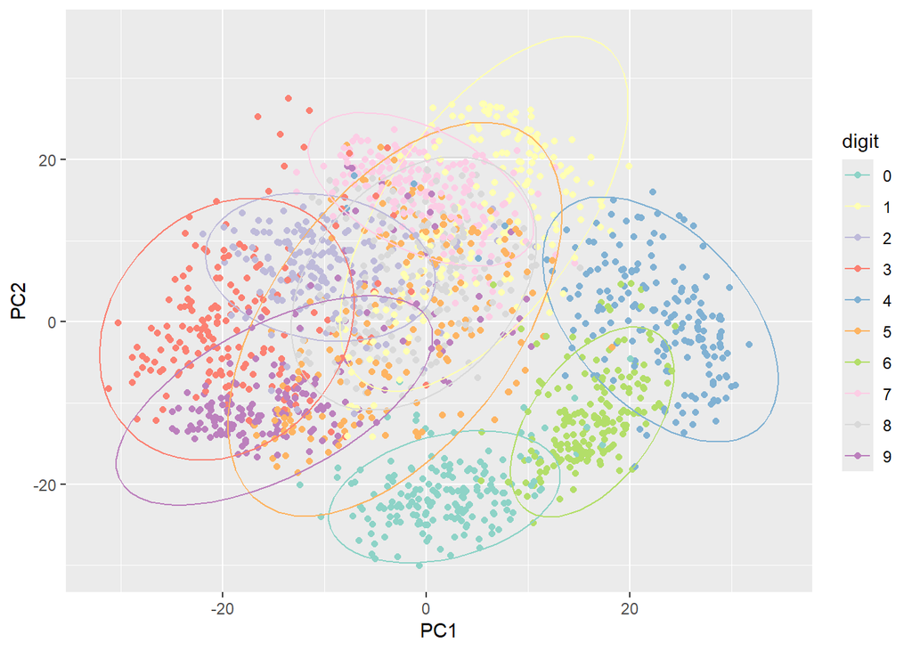

- Using PCA, we reduced the high-dimensional data of hand-written digit images into two dimensions
- The plot shows us the similarities within the hand-written digits (or clusters)
- If two clusters are intersecting, then it usually means that these hand-written digits can look similar an appearance.

# Activity: Implement PCA Visualizations

1. Log-in to Posit Cloud and open the R Studio assignment *MA13: Implement PCA Visualizations*.
2. Make sure you are in the current working directory. Rename the `.Rmd` file by replacing `[name]` with your name using the format `[First name][Last initial]`. Then, open the `.Rmd` file.
3. Change the author in the YAML header.
4. Read the provided instructions.
5. Answer all exercise problems on the designated sections.